# 开发 AI 应用 - 花卉分类器

本项目将训练一个图像分类器来识别不同的花卉品种（通过pytorch进行深度学习）。该项目很有实用价值，比如，可以应用于这样一款手机app：当对着花卉拍摄时，它能够识别这朵花的名称。完成该项目后，可以将代码导出到脚本文件中，通过在脚本中引入`argparse`模块，构建成一个命令行应用。

**数据集说明：**使用[此数据集](http://www.robots.ox.ac.uk/~vgg/data/flowers/102/index.html)，其中包含 102 个花卉类别。flowers文件夹下包含test，train，valid三个文件夹；train文件夹下包含102个文件夹，从1都102命名，每个文件即代表一种花卉，包含几十张左右该种类花卉的图片；test，valid文件夹结构同理，只是图片数量较少。

## 项目内容：

1. 加载和预处理图像数据集
2. 用数据集训练图像分类器
3. 使用训练的分类器预测图像内容

首先，导入所需的软件包。

```python
# Imports
%matplotlib inline
%config InlineBackend.figure_format = 'retina'

import os
import json
import numpy as np
import matplotlib.pyplot as plt
from PIL import Image

import torch
from torch import nn
from torch import optim
import torch.nn.functional as F
from torchvision import datasets, transforms, models
```

## 加载数据

使用 `torchvision` 加载数据（[文档](http://pytorch.org/docs/master/torchvision/transforms.html#)）。数据集分成三部分：训练集、验证集和测试集。对于训练集，1）需要变换数据，比如随机缩放、剪裁和翻转，有助于进行网络泛化，带来更好的效果；2）还需要将输入数据的大小调整为 224x224 像素，预训练的网络需要这么做。

验证集和测试集用于衡量模型对尚未见过的数据的预测效果，不需要进行任何缩放或旋转变换，但需要将图像剪裁到合适的大小。

对于三个数据集，都需要将均值和标准差标准化到网络期望的结果。均值为 `[0.485, 0.456, 0.406]`，标准差为 `[0.229, 0.224, 0.225]`。这样使得每个颜色通道的值位于 -1 到 1 之间，而不是 0 到 1。

```python
data_dir = 'flowers'
train_dir = 'train'
valid_dir = 'valid'
test_dir = 'test'
```

```python
# Define transforms for the training, validation, and testing sets
data_transforms = {'train': transforms.Compose([
                        transforms.RandomRotation(40),
                        transforms.RandomResizedCrop(224),
                        transforms.RandomHorizontalFlip(),
                        transforms.ToTensor(),
                        transforms.Normalize([0.485, 0.456, 0.406],
                                             [0.229, 0.224, 0.225])
                  ]),
                  'valid': transforms.Compose([
                      transforms.Resize(256),
                      transforms.CenterCrop(224),
                      transforms.ToTensor(),
                      transforms.Normalize([0.485, 0.456, 0.406],
                                           [0.229, 0.224, 0.225])
                  ]),
                  'test': transforms.Compose([
                      transforms.Resize(256),
                      transforms.CenterCrop(224),
                      transforms.ToTensor(),
                      transforms.Normalize([0.485, 0.456, 0.406],
                                           [0.229, 0.224, 0.225])
                  ])
}

# Load the datasets with ImageFolder
image_datasets = {x: datasets.ImageFolder(os.path.join(data_dir, x),
                                          transform=data_transforms[x])
                  for x in ['train', 'valid', 'test']}

# Using the image datasets and the trainforms, define the dataloaders
dataloaders = {x: torch.utils.data.DataLoader(image_datasets[x], batch_size=32,
                                             shuffle=True)
              for x in ['train', 'valid', 'test']}
```

### 标签映射

加载从类别标签到类别名称的映射。事先将映射信息放到了文件 `cat_to_name.json` 中。它是 JSON 对象，使用 [`json` 模块](https://docs.python.org/2/library/json.html)进行读取。最终得到一个从整数编码的类别到实际花卉名称的映射字典。

```python
with open('cat_to_name.json', 'r') as f:
    cat_to_name = json.load(f)
```

# 构建和训练分类器

数据准备好后，下面开始构建和训练分类器。

使用 `torchvision.models` 中的某个预训练模型获取图像特征。使用这些特征构建和训练新的前馈分类器。

训练分类器包括以下内容：

1. 加载[预训练的网络](http://pytorch.org/docs/master/torchvision/models.html)（本项目使用 VGG 网络，它比较简单易用）
2. 使用 ReLU 激活函数和丢弃定义新的未训练前馈网络作为分类器
3. 使用反向传播训练分类器层，并使用预训练的网络获取特征
4. 跟踪验证集的损失和准确率，以确定最佳超参数

tip：

1. 训练时，只更新前馈网络的权重。
2. 设置不同的参数（学习速率、分类器中的单元、周期等），不断尝试，才能找到最佳模型。
3. 每次训练都比较费时（及时在gpu模式下），所以要保存训练结果。

```python
# 判断gpu是否可用
device = torch.device('cuda:0' if torch.cuda.is_available() else 'cpu')
```

```python
# 加载预训练网络
model = models.vgg16(pretrained=True)
print(model)
```

```
Downloading: "https://download.pytorch.org/models/vgg16-397923af.pth" to /root/.torch/models/vgg16-397923af.pth
```

```
VGG(
  (features): Sequential(
    (0): Conv2d(3, 64, kernel_size=(3, 3), stride=(1, 1), padding=(1, 1))
    (1): ReLU(inplace)
    (2): Conv2d(64, 64, kernel_size=(3, 3), stride=(1, 1), padding=(1, 1))
    (3): ReLU(inplace)
    (4): MaxPool2d(kernel_size=2, stride=2, padding=0, dilation=1, ceil_mode=False)
    (5): Conv2d(64, 128, kernel_size=(3, 3), stride=(1, 1), padding=(1, 1))
    (6): ReLU(inplace)
    (7): Conv2d(128, 128, kernel_size=(3, 3), stride=(1, 1), padding=(1, 1))
    (8): ReLU(inplace)
    (9): MaxPool2d(kernel_size=2, stride=2, padding=0, dilation=1, ceil_mode=False)
    (10): Conv2d(128, 256, kernel_size=(3, 3), stride=(1, 1), padding=(1, 1))
    (11): ReLU(inplace)
    (12): Conv2d(256, 256, kernel_size=(3, 3), stride=(1, 1), padding=(1, 1))
    (13): ReLU(inplace)
    (14): Conv2d(256, 256, kernel_size=(3, 3), stride=(1, 1), padding=(1, 1))
    (15): ReLU(inplace)
    (16): MaxPool2d(kernel_size=2, stride=2, padding=0, dilation=1, ceil_mode=False)
    (17): Conv2d(256, 512, kernel_size=(3, 3), stride=(1, 1), padding=(1, 1))
    (18): ReLU(inplace)
    (19): Conv2d(512, 512, kernel_size=(3, 3), stride=(1, 1), padding=(1, 1))
    (20): ReLU(inplace)
    (21): Conv2d(512, 512, kernel_size=(3, 3), stride=(1, 1), padding=(1, 1))
    (22): ReLU(inplace)
    (23): MaxPool2d(kernel_size=2, stride=2, padding=0, dilation=1, ceil_mode=False)
    (24): Conv2d(512, 512, kernel_size=(3, 3), stride=(1, 1), padding=(1, 1))
    (25): ReLU(inplace)
    (26): Conv2d(512, 512, kernel_size=(3, 3), stride=(1, 1), padding=(1, 1))
    (27): ReLU(inplace)
    (28): Conv2d(512, 512, kernel_size=(3, 3), stride=(1, 1), padding=(1, 1))
    (29): ReLU(inplace)
    (30): MaxPool2d(kernel_size=2, stride=2, padding=0, dilation=1, ceil_mode=False)
  )
  (classifier): Sequential(
    (0): Linear(in_features=25088, out_features=4096, bias=True)
    (1): ReLU(inplace)
    (2): Dropout(p=0.5)
    (3): Linear(in_features=4096, out_features=4096, bias=True)
    (4): ReLU(inplace)
    (5): Dropout(p=0.5)
    (6): Linear(in_features=4096, out_features=1000, bias=True)
  )
)
```

```python
# 固定模型的参数
for param in model.parameters():
    param.requires_grad = False
```

```python
# 构造自己的分类器
class ClassifierNet(nn.Module):
    def __init__(self, input_size, output_size, hidden_layers, drop_p=0.5):
        ''' Builds a feedforward network with arbitrary hidden layers.

            Arguments
            ---------
            input_size: integer, size of the input
            output_size: integer, size of the output layer
            hidden_layers: list of integers, the sizes of the hidden layers
            drop_p: float between 0 and 1, dropout probability
        '''
        super().__init__()
        # Add the first layer, input to a hidden layer
        self.hidden_layers = nn.ModuleList([nn.Linear(input_size, hidden_layers[0])])

        # Add a variable number of more hidden layers
        layer_sizes = zip(hidden_layers[:-1], hidden_layers[1:])
        self.hidden_layers.extend([nn.Linear(h1, h2) for h1, h2 in layer_sizes])

        self.output = nn.Linear(hidden_layers[-1], output_size)

        self.dropout = nn.Dropout(p=drop_p)

    def forward(self, x):
        ''' Forward pass through the network, returns the output logits '''

        # Forward through each layer in `hidden_layers`, with ReLU activation and dropout
        for linear in self.hidden_layers:
            x = F.relu(linear(x))
            x = self.dropout(x)

        x = self.output(x)

        return F.log_softmax(x, dim=1)
```

```python
# 验证函数
def validation(model, testloader):
    model.eval()
    criterion = nn.NLLLoss()
    test_loss = 0
    accuracy = 0
    for images, labels in testloader:
        images, labels = images.to(device), labels.to(device)
        output = model.forward(images)
        test_loss += criterion(output, labels).item()  # 对每一批次进行累加

        ps = torch.exp(output)  # 分类器输出为log-softmax，所以需要exp
        equality = (labels.data == ps.max(dim=1)[1])
        accuracy += equality.type(torch.FloatTensor).mean()  # 对每一批次进行累加

    return test_loss/len(testloader), accuracy/len(testloader)
```

```python
# 训练函数
def do_deep_learning(model, epochs=5, lr=0.001, print_every=40, trainloader=dataloaders['train'], testloader=dataloaders['valid']):
    criterion = nn.NLLLoss()
    optimizer = optim.Adam(model.classifier.parameters(), lr=lr)

    steps = 0
    running_loss = 0
    for e in range(epochs):
        # 为以防万一，开启dropout功能
        model.train()
        model.to(device)

        for images, labels in trainloader:
            steps += 1

            images, labels = images.to(device), labels.to(device)

            optimizer.zero_grad()

            outputs = model.forward(images)
            loss = criterion(outputs, labels)
            loss.backward()
            optimizer.step()

            running_loss += loss.item()

            if steps % print_every == 0:
                # 进行验证时，不希望删除节点（dropout），所以设置为eval()模式
                model.eval()

                # 计算出损失值 和 预测准确率
                test_loss, accuracy = validation(model, dataloaders['valid'])

                print("Epoch: {}/{}.. ".format(e+1, epochs),
                      "Training Loss: {:.3f}.. ".format(running_loss/print_every),
                      "Test Loss: {:.3f}.. ".format(test_loss),
                      "Test Accuracy: {:.3f}".format(accuracy))

                running_loss = 0

                # 验证结束后再开启dropout功能
                model.train()
```

```python
# 替换model的分类器
input_size = model.classifier[0].in_features
output_size = len(image_datasets['train'].class_to_idx)
```

```python
# 设置隐藏层单元数500, drop_p=0.1
classifier = ClassifierNet(input_size, output_size, [500], drop_p=0.1)
model.classifier = classifier

# 训练模型, 设置epochs=4
do_deep_learning(model, epochs=4)
```

```
Epoch: 1/4..  Training Loss: 3.836..  Test Loss: 2.386..  Test Accuracy: 0.435
Epoch: 1/4..  Training Loss: 2.399..  Test Loss: 1.436..  Test Accuracy: 0.638
Epoch: 1/4..  Training Loss: 1.769..  Test Loss: 1.143..  Test Accuracy: 0.685
Epoch: 1/4..  Training Loss: 1.561..  Test Loss: 0.928..  Test Accuracy: 0.751
Epoch: 1/4..  Training Loss: 1.454..  Test Loss: 0.796..  Test Accuracy: 0.801
Epoch: 2/4..  Training Loss: 1.258..  Test Loss: 0.870..  Test Accuracy: 0.760
Epoch: 2/4..  Training Loss: 1.105..  Test Loss: 0.724..  Test Accuracy: 0.812
Epoch: 2/4..  Training Loss: 1.181..  Test Loss: 0.678..  Test Accuracy: 0.819
Epoch: 2/4..  Training Loss: 1.142..  Test Loss: 0.674..  Test Accuracy: 0.813
Epoch: 2/4..  Training Loss: 1.160..  Test Loss: 0.655..  Test Accuracy: 0.822
Epoch: 3/4..  Training Loss: 1.031..  Test Loss: 0.629..  Test Accuracy: 0.831
Epoch: 3/4..  Training Loss: 0.915..  Test Loss: 0.561..  Test Accuracy: 0.854
Epoch: 3/4..  Training Loss: 0.964..  Test Loss: 0.520..  Test Accuracy: 0.841
Epoch: 3/4..  Training Loss: 0.972..  Test Loss: 0.558..  Test Accuracy: 0.850
Epoch: 3/4..  Training Loss: 0.958..  Test Loss: 0.527..  Test Accuracy: 0.864
Epoch: 4/4..  Training Loss: 0.865..  Test Loss: 0.577..  Test Accuracy: 0.849
Epoch: 4/4..  Training Loss: 0.913..  Test Loss: 0.507..  Test Accuracy: 0.861
Epoch: 4/4..  Training Loss: 0.855..  Test Loss: 0.541..  Test Accuracy: 0.860
Epoch: 4/4..  Training Loss: 0.900..  Test Loss: 0.514..  Test Accuracy: 0.868
Epoch: 4/4..  Training Loss: 0.878..  Test Loss: 0.532..  Test Accuracy: 0.863
```

## 测试网络

使用在训练和验证过程中从未见过的测试数据测试 训练好的网络。这样，才能很好地判断模型预测全新图像的效果。用训练好的模型识别测试图像集，返回准确率（同验证过程一样）。

```python
validation(model, dataloaders['test'])
```

```
(0.5634853530388612, tensor(0.8537))
```

对测试集数据进行预测，准确率高达85.4%。

## 保存检查点

训练好网络后 1）保存模型，这样结束当前kernel后再返回，就无需重新训练，只用加载检查点即可；2）还要保存从类别到索引的映射，索引是从图像数据集中获取的：`image_datasets['train'].class_to_idx`，将其作为属性附加到模型上，之后工作会更方便。

```python
checkpoint = {'input_size': input_size,
             'output_size': output_size,
             'hidden_layers': [each.out_features for each in model.classifier.hidden_layers],
             'state_dict': model.classifier.state_dict(),
            'class_to_idx': image_datasets['train'].class_to_idx}

torch.save(checkpoint, 'checkpoint.pth')
```

## 加载检查点

写一个可以加载检查点并重新构建模型的函数。

```python
# Write a function that loads a checkpoint and rebuilds the model
def load_checkpoint(filepath):
    # 分类器
    checkpoint = torch.load(filepath)
    classifier = ClassifierNet(checkpoint['input_size'],
                               checkpoint['output_size'],
                               checkpoint['hidden_layers'])
    classifier.load_state_dict(checkpoint['state_dict'])

    class_to_idx = checkpoint['class_to_idx']

    # 神经网络
    model = models.vgg16(pretrained=True)
    model.classifier = classifier

    return model, class_to_idx
```

```python
# 重新载入模型
model, class_to_idx = load_checkpoint('checkpoint.pth')
```

```python
# 检查其准确率是否跟之前一致
validation(model.to(device), dataloaders['test'])
```

```
(0.5666722007668935, tensor(0.8529))
```

# 类别判断

最后一部分，用训练好的神经网络进行类别判断。即向网络中传入一个图像，能够预测出图像中的花卉类别。

## 图像处理

将图片输入神经网络之前，先处理输入花卉图像 使其满足网络的要求。使用 `PIL` 加载图像（[文档](https://pillow.readthedocs.io/en/latest/reference/Image.html)）。将图像处理过程封装为函数，该函数按照和训练的相同方式处理花卉图像。

首先，调整图像大小，使最小的边为 256 像素，并保持宽高比。使用 [`thumbnail`](http://pillow.readthedocs.io/en/3.1.x/reference/Image.html#PIL.Image.Image.thumbnail) 或 [`resize`](http://pillow.readthedocs.io/en/3.1.x/reference/Image.html#PIL.Image.Image.thumbnail) 方法。然后，从图像的中心裁剪出 224x224 的部分。

图像的颜色通道通常编码为整数 0-255，但是该模型要求值为浮点数 0-1，所以需要进行值变换。使用 Numpy 数组从 PIL 图像中获取数据，类似 `np_image = np.array(pil_image)`。

和之前一样，模型要求图像输入之前先按照特定的方式标准化。均值 标准化为 `[0.485, 0.456, 0.406]`，标准差 标准化为 `[0.229, 0.224, 0.225]`。用每个颜色通道减去均值，然后除以标准差。

PyTorch 要求颜色通道为第一个维度，但是在 PIL 图像和 Numpy 数组中是第三个维度。所以使用 [`ndarray.transpose`](https://docs.scipy.org/doc/numpy-1.13.0/reference/generated/numpy.ndarray.transpose.html)对维度重新排序。颜色通道放在第一个维度，同时保持另外两个维度的顺序。

```python
# 用PIL进行图像变换
def process_image(image):
    ''' Scales, crops, and normalizes a PIL image for a PyTorch model,
        returns an Numpy array
    '''
    # Process a PIL image for use in a PyTorch model
    im = Image.open(image)
    # scale
    w, h = im.size
    if w < h:
        pair = (256, int(256/w * h))
    else:
        pair = (int(256/h * w), 256)
    im = im.resize(pair)

    # crop
    w, h = im.size  ## 重新取图片的宽高
    new_w, new_h = 224, 224
    left = (w - new_w)/2
    upper = (h - new_h)/2
    right = (w + new_w)/2
    lower = (h + new_h)/2

    im = im.crop((left, upper, right, lower))

    # normalize
    mean = np.array([0.485, 0.456, 0.406])
    std = np.array([0.229, 0.224, 0.225])
    np_im = np.array(im)
    np_im = np_im/255
    np_im = (np_im - mean)/std

    np_im = np_im.transpose(2,0,1)

    # 转化为pytorch.tensor输出
    return torch.from_numpy(np_im)
```

检查 `process_image` 函数是否可行，如果正确，运行以下 `imshow` 函数会返回原始图像（剪裁掉的部分除外）。

```python
def imshow(image, ax=None, title=None):
    """Imshow for Tensor."""
    if ax is None:
        fig, ax = plt.subplots()

    # PyTorch tensors assume the color channel is the first dimension
    # but matplotlib assumes is the third dimension
    image = image.numpy().transpose((1, 2, 0))

    # Undo preprocessing
    mean = np.array([0.485, 0.456, 0.406])
    std = np.array([0.229, 0.224, 0.225])
    image = std * image + mean

    # Image needs to be clipped between 0 and 1 or it looks like noise when displayed
    image = np.clip(image, 0, 1)

    ax.imshow(image)

    return ax
```

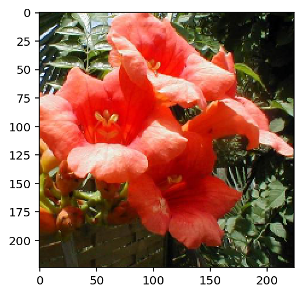

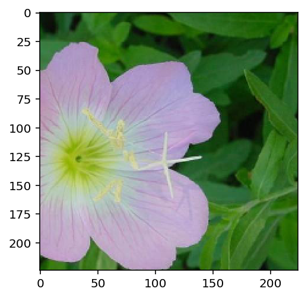

```python
# 测试图像处理是否正确
img1 = process_image("flowers/train/101/image_07996.jpg")
imshow(img1)
plt.show()

img2 = process_image("flowers/train/1/image_06735.jpg")
imshow(img2)
plt.show()
```

从显示结果来看，`process_image` 函数运行正常。

## 类别预测

图像格式处理之后，下面进行真正的预测。

`predict`函数接受两个参数：图像路径和模型，并返回概率和类别。效果如下：

```
probs, classes = predict(image_path, model)
print(probs)
print(classes)
> [ 0.01558163  0.01541934  0.01452626  0.01443549  0.01407339]
> ['70', '3', '45', '62', '55']
```

```python
def predict(image_path, model, topk=5):
    ''' Predict the class (or classes) of an image using a trained deep learning model.
    '''

    # Implement the code to predict the class from an image file
    img_tensor = process_image(image_path)
    img_tensor.unsqueeze_(0)
    if device == 'cpu':
        img_tensor = img_tensor.type(torch.FloatTensor)
    else:
        img_tensor = img_tensor.type(torch.cuda.FloatTensor)
    img_tensor.to(device)

    model.eval()
    model.to(device)
    output = model.forward(img_tensor)
    ps = torch.exp(output)  # 当前图片的预测结果
    probs, inds = ps.topk(topk)  # 返回排名前几的概率和索引
    probs = probs.cpu().detach().numpy()[0]  # 将tensor(cpu)转为numpy.array
    inds = inds.cpu().detach().numpy()[0]  # 将tensor(cpu)转为numpy.array

    class_to_idx = image_datasets['train'].class_to_idx
    idx_to_class = {val:key for key,val in class_to_idx.items()}
    classes = [idx_to_class[i] for i in inds]

    return probs, classes
```

## 检查运行状况

再结合`predict`函数，使用 `matplotlib` 将预测结果可视化，输出原花卉图像和前5个类别概率的条形图。

```python
# Display an image along with the top 5 classes
def show_result(image_path, model, class_name):
    plt.figure(figsize=(8,8))

    # 显示原图片
    plt.subplot(2,1,1)
    plt.title(cat_to_name[class_name])
    plt.axis('on')
    img = plt.imread(image_path)
    plt.imshow(img)

    # 显示预测前几的结果
    probs, classes = predict(image_path, model)
    names = [cat_to_name[i] for i in classes]
    plt.subplot(2,1,2)
    plt.barh(names, probs)
    plt.show()
```

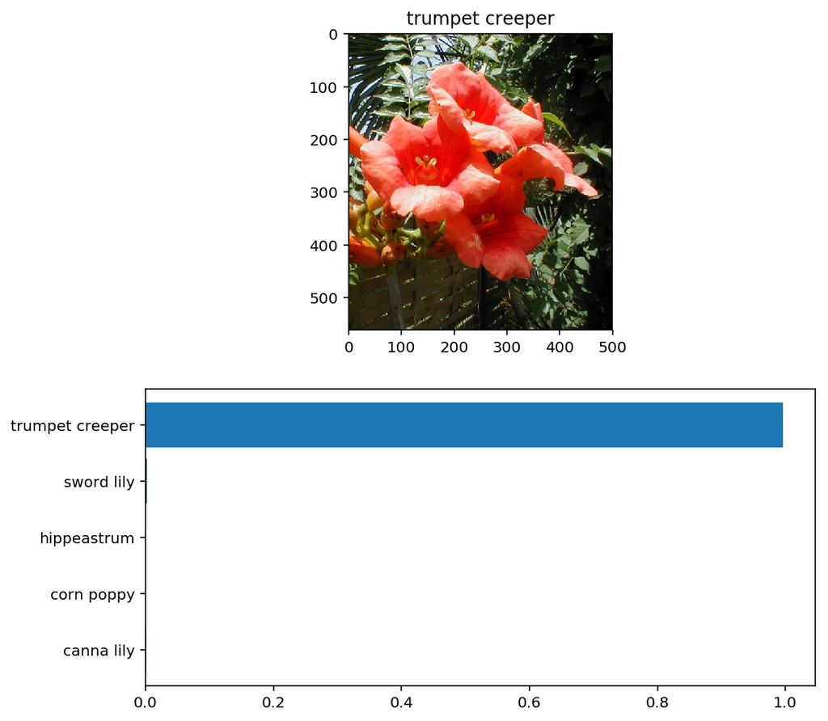

```python
show_result("flowers/train/101/image_07996.jpg", model, '101')
```

从以上结果可以看出，训练之后的神经网络 准确地预测出了花卉类别。（原图像为trumpet creeper，预测结果第一位也是trumpet creeper，且概率接近1）

太奇怪了，为什么后面的不能显示。难道有cell个数的限制？